# Wellbeing and lifestyle data

## 1. Description and objetives

This dataset from Kaggle.com (https://www.kaggle.com/ydalat/lifestyle-and-wellbeing-data) contains 12,757 survey responses with 23 attributes describing how we live our lives. How can we reinvent our lifestyles to optimize our individual wellbeing while supporting the UN Sustainable Development Goals?

Your Work-Life Balance survey evaluates how we thrive in both your professional and personal lives: it reflects how well you shape your lifestyle, habits and behaviors to maximize your overall life satisfaction along the following five dimensions:

1. Healthy body, reflecting your fitness and healthy habits;
2. Healthy mind, indicating how well you embrace positive emotions;
3. Expertise, measuring the ability to grow your expertise and achieve something unique;
4. Connection, assessing the strength of your social network and your inclination to discover the world;
5. Meaning, evaluating your compassion, generosity and how much 'you are living the life of your dream'.

### Description

This is a description of the attributes in the dataset:

```python
%run wellbeing_description.py
```

|  | Variable | Description | Values | Type of attribute |
| --- | --- | --- | --- | --- |
| 0 | Timestamp | Date of the survey | 7/7/15 - 24/2/2020 | Ordinal, object |
| 1 | Fruits_Veggies | How many fruits or veggies do you eat everyday? | 0 - 5 | Numerical, int 64 |
| 2 | Daily_stress | How much stress so you typically experience everyday? In average, over 12 months | 0 - 5 | Numerical, object |
| 3 | Places_visited | How many places do you visit? Over a period of 12 months. Include new states, new cities, etc. | 0 - 10 | Numerical, int 64 |
| 4 | Core_circle | How many people are very close to you? i.e. close family and friends | 0 - 10 | Numerical, int 64 |
| 5 | Supporting others | How many people do you help achieve a better life? A reflection of your altruism. Over a period of 12 months. | 0 - 10 | Numerical, int 64 |
| 6 | Social_network | How many people do you interact with during a typical day? At home, at work... Average of workdays and weekends | 0 - 10 | Numerical, int 64 |
| 7 | Achievement | How many remarkable achievements are you proud of? Over the last 12 months, such as running a marathon, success at work, opening a new business, etc. | 0 - 10 | Numerical, int 64 |
| 8 | Donation | How many times do you donate your time or money to good causes? Over a period of 12 months | 0 - 5 | Numerical, int 64 |
| 9 | BMI_Range | What is your body mass index range? Your body mass in kg divided by the square of your height in meters. | 1 - 2 | Numerical, int 64 |
| 10 | Todo_completed | How well do you complete your weekly to-do list? Include work- and personal-related tasks. On a scale of 0 = not at all to 10 = very well | 0 - 10 | Numerical, int 64 |
| 11 | Flow | How many hours do you experience 'flow'? 'Flow' is defined as the mental state, in which you are fully immersed in performing an activity | 0 - 10 | Numerical, int 64 |
| 12 | Daily_steps | How many steps (in thousands) do you typically walk everyday? Thousand steps, daily average over multiple days including work days and week-end | 1 - 10 | Numerical, int 64 |
| 13 | Live_vision | For how many years ahead is your life vision very clear for? For instance, illustrated in a vision board or discussed with a friend | 0 - 10 | Numerical, int 64 |
| 14 | Sleep_hours | About how long do you typically sleep? Over the course of a typical working week, including week-end. | 1 - 10 | Numerical, int 64 |
| 15 | Lost_vacation | How many days of vacation do you typically lose every year? Unused vacation days, lost or carried forward into the following year, etc. | 0 - 10 | Numerical, int 64 |
| 16 | Daily_shouting | How often do you shout or sulk at somebody? In a typical week. Expressing your negative emotions in an active or passive manner. | 0 - 10 | Numerical, int 64 |
| 17 | Sufficient_income | How sufficient is your income to cover basic life expenses? Such as the costs of housing, food, health care, car and education. | 1 - 2 | Numerical, int 64 |
| 18 | Personal_awards | How many recognitions have you received in your life? E.g. diploma, degree, certificate, accreditation, award, prize, etc. | 0 - 10 | Numerical, int 64 |
| 19 | Time_for_passion | How many hours do you spend everyday doing what you are passionate about? Daily hours spent doing what you are passionate and dreaming about | 0 - 10 | Numerical, int 64 |
| 20 | Daily_meditation | How many times during the day do you think about yourself in a typical week? Include meditation, praying and relaxation activities such as fitness, walking in a park or lunch breaks. | 0 - 10 | Numerical, int 64 |
| 21 | Age | Age groups | 21 to 35 - Less than 20 | Ratio Scaled, object |
| 22 | Gender | Male or female | Female - Male | Nominal, object |

### Objetives

We are looking for findings that might help us to get success and improve our quality of life. In particular, we'll try to answer these questions:

1. Achievements: What indicators have the greatest influence in our achievements and how well can we predict them?
1. Stress levels: What indicators have the greatest influence in our stress levels and how well can we predict it? For this variable, we will perform some linear models being the interpretation the main goal, so finding the largest coefficients in the predictive model is what we are intereseted in, as well as the statistical significance of these coefficients, so that we get the features having the most influence on our daily stress and take action to hopefully reduce it.

From the conclusion we reach to, we can modify some habits to maximize our achievements an reduce our stress levels

## 2. Exploratory Data Analysis

This is the general guide line followed for the EDA in the project:

**2.1 Data Exploration:** Exploration of the values and data types.

**2.2 Data cleaning:** Clean the data, handling possible wrong values, NaN and outliers, and changing the data types to numeric (integers) when possible to perform numerical data analysis.

**2.3 Feature engineering:** Create encoding from categorical variables, such as ordinal encoding for age, binary encoding and dummy variables for gender

**2.4 Data statistics:** See statistic measures with the method *describe*: mean, standard deviation, max, min and quartiles. Plot histograms and boxplots for all the variables

**2.5 Correlations between variables:** Look for correlations between variables

**2.6 Summary of the EDA: Key Findings and insights**

### 2.1 Data Exploration

#### Initial plan:

We are going to explore the raw dataset. I'll check the values and data types, looking for possible wrong values, Nan or missings.

From the description, we saw that the variable *stress_level* is numerical, but it is of type object. There might be some values which are not numbers, and therefore the data type of the variable is "object". We'll see it in the exploration of unique values with the *unique* method of pd.Series. Next during the *data cleaning* (section 2.2) I'll handle this wrong values, either dropping the entire rows if there are not too many of these values, or imputing them from the variable mean.

The variables *age* and *gender* are objects. I'll see the categories in which *age* is divided, and next during the *feature engineering* (section 2.3) I'll perform an ordinal encoding to be able to plot a histogram of the *age* while performing *data statistics* (section 2.4). With respect to gender, a binary encoding can be done with view to use it in a future predictive model.

Once I have all the variables cleaned and appropiately treated in the case of categorical features, I am ready to plot histograms and boxplots to search possible outliers that we'll handle. Finally, I'll look for the highest positive and negative correlations, specially between the variable *stress level* and the others, and between *achievement* and the others. In this last section and looking the description of the variables, we can expect negative correlations with *stress level* in general and positive correlations with *achievement*.

```python
import pandas as pd
import numpy as np

import seaborn as sns
import matplotlib.pyplot as plt

from sklearn.preprocessing import OrdinalEncoder

import math
```

```python
data = pd.read_csv('Wellbeing_and_lifestyle_data.csv')
```

```python
data.head()
```

|  | Timestamp | FRUITS_VEGGIES | DAILY_STRESS | PLACES_VISITED | CORE_CIRCLE | SUPPORTING_OTHERS | SOCIAL_NETWORK | ACHIEVEMENT | DONATION | BMI_RANGE | ... | LIVE_VISION | SLEEP_HOURS | LOST_VACATION | DAILY_SHOUTING | SUFFICIENT_INCOME | PERSONAL_AWARDS | TIME_FOR_PASSION | DAILY_MEDITATION | AGE | GENDER |
| --- | --- | --- | --- | --- | --- | --- | --- | --- | --- | --- | --- | --- | --- | --- | --- | --- | --- | --- | --- | --- | --- |
| 0 | 7/7/15 | 3 | 2 | 2 | 5 | 0 | 5 | 2 | 0 | 1 | ... | 0 | 7 | 5 | 5 | 1 | 4 | 0 | 5 | 36 to 50 | Female |
| 1 | 7/7/15 | 2 | 3 | 4 | 3 | 8 | 10 | 5 | 2 | 2 | ... | 5 | 8 | 2 | 2 | 2 | 3 | 2 | 6 | 36 to 50 | Female |
| 2 | 7/7/15 | 2 | 3 | 3 | 4 | 4 | 10 | 3 | 2 | 2 | ... | 5 | 8 | 10 | 2 | 2 | 4 | 8 | 3 | 36 to 50 | Female |
| 3 | 7/7/15 | 3 | 3 | 10 | 3 | 10 | 7 | 2 | 5 | 2 | ... | 0 | 5 | 7 | 5 | 1 | 5 | 2 | 0 | 51 or more | Female |
| 4 | 7/7/15 | 5 | 1 | 3 | 3 | 10 | 4 | 2 | 4 | 2 | ... | 0 | 7 | 0 | 0 | 2 | 8 | 1 | 5 | 51 or more | Female |

5 rows × 23 columns

```python
# Is there any NaN?
data.isnull().values.any()
```

```
False
```

```python
#Number of rows and columns
print("Number of data points: {}".format(data.shape[0]), "\nNumber of variables: {}".format(data.shape[1]))

#Column names, data types and counts
data_types = data.dtypes
data_counts = data.count()
df = pd.concat([data_types, data_counts], axis=1).reset_index()
df = df.rename(columns={'index': 'Column names' , 0: 'Types', 1: 'Counts'})
print("\nData types:\n{}".format(df))
```

```
Number of data points: 12756
Number of variables: 23

Data types:
         Column names   Types  Counts
0           Timestamp  object   12756
1      FRUITS_VEGGIES   int64   12756
2        DAILY_STRESS  object   12756
3      PLACES_VISITED   int64   12756
4         CORE_CIRCLE   int64   12756
5   SUPPORTING_OTHERS   int64   12756
6      SOCIAL_NETWORK   int64   12756
7         ACHIEVEMENT   int64   12756
8            DONATION   int64   12756
9           BMI_RANGE   int64   12756
10     TODO_COMPLETED   int64   12756
11               FLOW   int64   12756
12        DAILY_STEPS   int64   12756
13        LIVE_VISION   int64   12756
14        SLEEP_HOURS   int64   12756
15      LOST_VACATION   int64   12756
16     DAILY_SHOUTING   int64   12756
17  SUFFICIENT_INCOME   int64   12756
18    PERSONAL_AWARDS   int64   12756
19   TIME_FOR_PASSION   int64   12756
20   DAILY_MEDITATION   int64   12756
21                AGE  object   12756
22             GENDER  object   12756
```

It is a dataset with Number of data points: 12756 points (rows) and 23 variables (columns). There are no missings or NaNs

```python
#Let's change the column names to lowercase
data.columns = pd.Index(data.columns.str.lower())
data.columns
```

```
Index(['timestamp', 'fruits_veggies', 'daily_stress', 'places_visited',
       'core_circle', 'supporting_others', 'social_network', 'achievement',
       'donation', 'bmi_range', 'todo_completed', 'flow', 'daily_steps',
       'live_vision', 'sleep_hours', 'lost_vacation', 'daily_shouting',
       'sufficient_income', 'personal_awards', 'time_for_passion',
       'daily_meditation', 'age', 'gender'],
      dtype='object')
```

**Unique values**

```python
for col in data.columns:
    print(col, data[col].unique())
```

```
timestamp ['7/7/15' '7/8/15' '7/9/15' ... '2/24/2020 10:35:02' '2/24/2020 12:54:10'
 '2/24/2020 12:55:21']
fruits_veggies [3 2 5 4 1 0]
daily_stress ['2' '3' '1' '4' '5' '0' '1/1/00']
places_visited [ 2  4  3 10  5  6  7  0  8  1  9]
core_circle [ 5  3  4  9  6  7  8 10  2  1  0]
supporting_others [ 0  8  4 10  5  3  1  2  6  7  9]
social_network [ 5 10  7  4  3  1  2  8  6  9  0]
achievement [ 2  5  3  4  0  1  6 10  8  7  9]
donation [0 2 5 4 3 1]
bmi_range [1 2]
todo_completed [ 6  5  2  3  8 10  7  4  1  0  9]
flow [ 4  2  5  0  1  8  7  6  3 10  9]
daily_steps [ 5  4  7  8  1  3  6  2 10  9]
live_vision [ 0  5 10  4  2  1  6  3  8  9  7]
sleep_hours [ 7  8  5  6 10  9  4  3  2  1]
lost_vacation [ 5  2 10  7  0  3  1  4  8  6  9]
daily_shouting [ 5  2  0  3  1  7  6  4 10  8  9]
sufficient_income [1 2]
personal_awards [ 4  3  5  8 10  1  2  7  6  0  9]
time_for_passion [ 0  2  8  1  3  6  5  4 10  9  7]
daily_meditation [ 5  6  3  0 10  2  1  7  4  8  9]
age ['36 to 50' '51 or more' '21 to 35' 'Less than 20']
gender ['Female' 'Male']
```

```python
(data['daily_stress']=='1/1/00').sum()
```

```
1
```

*Daily stress:* There is a wrong value for *daily stress* (1/1/00), but as it is only one, I'll just drop the entire row (next section)  
*Age*: There are 4 categories of age. In the section "feature engineering" we'll perform the ordinal encoding.

### 2.2 Data cleaning

As there are no nulls, missing or strange values except the one in *daily stress*, the data cleaning will cosist only in eliminate the row corresponing to the value 1/1/00 of *'daily stress'* and change it to type int64.

NOTE: The visualizations of data (histograms and boxplots) will be done in the section *data statistics* (2.4), once we perform a initial cleaning an encoding, and a later cleaning would be done for outliers, if required

#### Cleaning variables: daily stress

There is only one strange value of daily_stress, so we can just drop the entire row from the dataset. Then I am going to change the data type from object to integer:

```python
data = data.drop(data[data['daily_stress']=='1/1/00'].index)
data.shape
```

```
(12755, 23)
```

```python
# Changing data type from object to int64
data['daily_stress'] = data['daily_stress'].astype('int64')
```

### 2.3 Feature engineering

In this section we have to handle 2 categorical variables:

- Age: We are going to perform an ordinal encoding, changing the categories to ordered integers
- Gender: We are going to perform an binary encoding, changing the categories to ordered integers:

#### Processing categorical variables: age

We are going to perform an **ordinal encoding**, changing the categories to ordered integers:

```python
age_categories = ['Less than 20','21 to 35','36 to 50','51 or more'] #data['age'].unique(), but in the order we want

enc = OrdinalEncoder(categories=[age_categories])
enc.fit(np.array(data['age']).reshape(-1,1)) #Alternatively: Method fit_transform = method fit + method transform
                                #An array of shape (n_categories, n_features) should be passed to fit --> reshape(-1,1)
enc.categories
```

```
[['Less than 20', '21 to 35', '36 to 50', '51 or more']]
```

```python
age_encoded = enc.transform(np.array(data['age']).reshape(-1,1))
age_encoded
```

```
array([[2.],
       [2.],
       [2.],
       ...,
       [2.],
       [1.],
       [3.]])
```

```python
np.unique(age_encoded)
```

```
array([0., 1., 2., 3.])
```

```python
age_original = enc.inverse_transform(age_encoded)
age_original
```

```
array([['36 to 50'],
       ['36 to 50'],
       ['36 to 50'],
       ...,
       ['36 to 50'],
       ['21 to 35'],
       ['51 or more']], dtype=object)
```

```python
# Verification
enc.inverse_transform([[code] for code in [0,1,2,3]])
```

```
array([['Less than 20'],
       ['21 to 35'],
       ['36 to 50'],
       ['51 or more']], dtype=object)
```

```python
data['age'] = age_encoded
```

#### Processing categorial variables: gender

We are going to perform an **binary encoding**, changing the categories to ordered integers:

```python
data['gender'].unique()
```

```
array(['Female', 'Male'], dtype=object)
```

```python
pd.get_dummies(data['gender'], drop_first=True)
```

|  | Male |
| --- | --- |
| 0 | 0 |
| 1 | 0 |
| 2 | 0 |
| 3 | 0 |
| 4 | 0 |
| ... | ... |
| 12751 | 0 |
| 12752 | 0 |
| 12753 | 0 |
| 12754 | 0 |
| 12755 | 0 |

12755 rows × 1 columns

```python
gender_translator = {'Female': 0, 'Male': 1}
print(gender_translator)
```

```
{'Female': 0, 'Male': 1}
```

```python
data['gender'] = pd.get_dummies(data['gender'], drop_first=True)
d = {'Male': 'Gender (Female:0, Male: 1)'}
data.rename(columns=d)
```

|  | timestamp | fruits_veggies | daily_stress | places_visited | core_circle | supporting_others | social_network | achievement | donation | bmi_range | ... | live_vision | sleep_hours | lost_vacation | daily_shouting | sufficient_income | personal_awards | time_for_passion | daily_meditation | age | gender |
| --- | --- | --- | --- | --- | --- | --- | --- | --- | --- | --- | --- | --- | --- | --- | --- | --- | --- | --- | --- | --- | --- |
| 0 | 7/7/15 | 3 | 2 | 2 | 5 | 0 | 5 | 2 | 0 | 1 | ... | 0 | 7 | 5 | 5 | 1 | 4 | 0 | 5 | 2.0 | 0 |
| 1 | 7/7/15 | 2 | 3 | 4 | 3 | 8 | 10 | 5 | 2 | 2 | ... | 5 | 8 | 2 | 2 | 2 | 3 | 2 | 6 | 2.0 | 0 |
| 2 | 7/7/15 | 2 | 3 | 3 | 4 | 4 | 10 | 3 | 2 | 2 | ... | 5 | 8 | 10 | 2 | 2 | 4 | 8 | 3 | 2.0 | 0 |
| 3 | 7/7/15 | 3 | 3 | 10 | 3 | 10 | 7 | 2 | 5 | 2 | ... | 0 | 5 | 7 | 5 | 1 | 5 | 2 | 0 | 3.0 | 0 |
| 4 | 7/7/15 | 5 | 1 | 3 | 3 | 10 | 4 | 2 | 4 | 2 | ... | 0 | 7 | 0 | 0 | 2 | 8 | 1 | 5 | 3.0 | 0 |
| ... | ... | ... | ... | ... | ... | ... | ... | ... | ... | ... | ... | ... | ... | ... | ... | ... | ... | ... | ... | ... | ... |
| 12751 | 2/23/2020 22:03:56 | 3 | 4 | 10 | 8 | 10 | 8 | 6 | 5 | 1 | ... | 3 | 7 | 0 | 1 | 1 | 10 | 6 | 7 | 1.0 | 0 |
| 12752 | 2/24/2020 2:44:30 | 3 | 3 | 6 | 5 | 2 | 5 | 1 | 0 | 2 | ... | 0 | 7 | 0 | 0 | 2 | 3 | 0 | 2 | 2.0 | 0 |
| 12753 | 2/24/2020 10:35:02 | 4 | 4 | 7 | 5 | 3 | 3 | 4 | 2 | 1 | ... | 5 | 6 | 0 | 2 | 2 | 6 | 3 | 5 | 2.0 | 0 |
| 12754 | 2/24/2020 12:54:10 | 3 | 3 | 10 | 4 | 8 | 10 | 3 | 3 | 1 | ... | 1 | 6 | 0 | 1 | 1 | 10 | 1 | 10 | 1.0 | 0 |
| 12755 | 2/24/2020 12:55:21 | 2 | 2 | 6 | 1 | 6 | 1 | 5 | 2 | 1 | ... | 0 | 7 | 0 | 1 | 2 | 3 | 2 | 10 | 3.0 | 0 |

12755 rows × 23 columns

### 2.4 Data statistics and visualizations

#### Description

```python
description = data.describe()
description.loc["range"] = description.loc['max'] - description.loc['min']
out_fields = ["mean", "25%", "50%", "75%", "range"]
description = description.loc[out_fields]
description.transpose()
```

|  | mean | 25% | 50% | 75% | range |
| --- | --- | --- | --- | --- | --- |
| fruits_veggies | 2.930223 | 2.0 | 3.0 | 4.0 | 5.0 |
| daily_stress | 2.782673 | 2.0 | 3.0 | 4.0 | 5.0 |
| places_visited | 5.339240 | 3.0 | 5.0 | 8.0 | 10.0 |
| core_circle | 5.484908 | 3.0 | 5.0 | 8.0 | 10.0 |
| supporting_others | 5.577421 | 3.0 | 5.0 | 10.0 | 10.0 |
| social_network | 6.551156 | 4.0 | 6.0 | 10.0 | 10.0 |
| achievement | 3.963230 | 2.0 | 3.0 | 6.0 | 10.0 |
| donation | 2.700745 | 1.0 | 3.0 | 5.0 | 5.0 |
| bmi_range | 1.400706 | 1.0 | 1.0 | 2.0 | 1.0 |
| todo_completed | 5.706233 | 4.0 | 6.0 | 8.0 | 10.0 |
| flow | 3.126382 | 1.0 | 3.0 | 4.0 | 10.0 |
| daily_steps | 5.704822 | 3.0 | 5.0 | 8.0 | 9.0 |
| live_vision | 3.712034 | 1.0 | 3.0 | 5.0 | 10.0 |
| sleep_hours | 7.035202 | 6.0 | 7.0 | 8.0 | 9.0 |
| lost_vacation | 2.832536 | 0.0 | 0.0 | 5.0 | 10.0 |
| daily_shouting | 2.920659 | 1.0 | 2.0 | 4.0 | 10.0 |
| sufficient_income | 1.728185 | 1.0 | 2.0 | 2.0 | 1.0 |
| personal_awards | 5.702626 | 3.0 | 5.0 | 9.0 | 10.0 |
| time_for_passion | 3.266484 | 1.0 | 2.0 | 5.0 | 10.0 |
| daily_meditation | 6.253156 | 4.0 | 7.0 | 10.0 | 10.0 |
| age | 1.581968 | 1.0 | 1.0 | 2.0 | 3.0 |
| gender | 0.395218 | 0.0 | 0.0 | 1.0 | 1.0 |

**Boxplots**

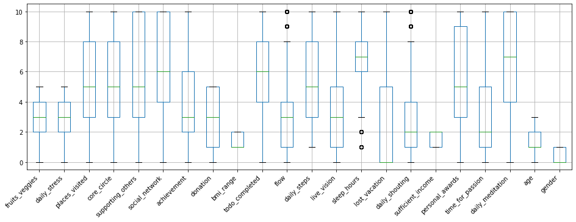

```python
# Boxplots

fig, axes = plt.subplots(figsize=(16,5))

data.boxplot()

for tick in axes.get_xticklabels():
    tick.set_rotation(45)
    tick.set_ha('right') #Horizontal alignment

plt.show()
```

```python
n_outliers = data['daily_shouting'][data['daily_shouting']>8].shape[0]
p = n_outliers/data.shape[0]
print("{} values above 1.5·range from Q3 = 8h of daily shouting \n{}% of data".format(n_outliers, round(p*100,2)))
```

```
753 values above 1.5·range from Q3 = 8h of daily shouting
5.9% of data
```

```python
n_outliers = data['flow'][data['flow']>8].shape[0]
p = n_outliers/data.shape[0]
print("{} values above 1.5·range from Q3 = 8h of daily flow \n{}% of data".format(n_outliers, round(p*100,2)))
```

```
374 values above 1.5·range from Q3 = 8h of daily flow
2.93% of data
```

```python
n_outliers = data['sleep_hours'][data['sleep_hours']<3].shape[0]
p = n_outliers/data.shape[0]
print("{} values below 1.5·range from Q1 = 3h of daily sleep \n{}% of data".format(n_outliers, round(p*100,2)))
```

```
32 values below 1.5·range from Q1 = 3h of daily sleep
0.25% of data
```

We decide to keep outliers as they might be meaningfull, representing the reality of population. Besides, they are not excessive to make us think of them as errors

#### Histograms

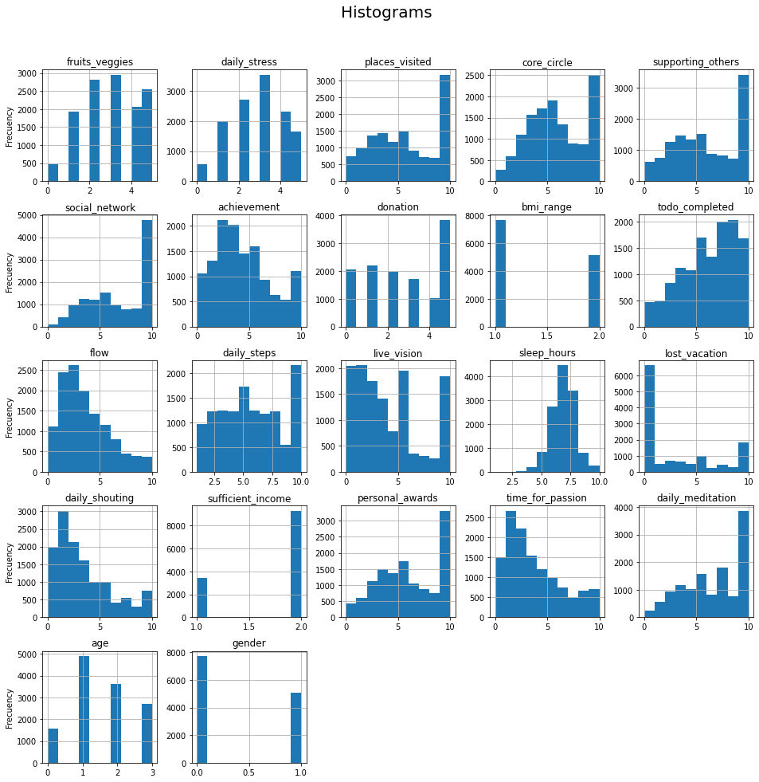

```python
# Histograms numerical variables

axs = data.hist(figsize=(16, 16))

for ax in axs.flatten():
    if ax.is_first_col():
        ax.set_ylabel('Frecuency')

plt.suptitle('Histograms', y=0.95, fontsize=20)
plt.show()
```

### 2.5 Correlations between variables

Correlation coefficients tell us about how well the variables are related by a straight line. However, it doesn't give any information about how much one influence to the other. For this purpose, we would have to perform a linear regression model, what we'll do later. Now let's see the correlations (Pearson).

```python
data.corr()
```

|  | fruits_veggies | daily_stress | places_visited | core_circle | supporting_others | social_network | achievement | donation | bmi_range | todo_completed | ... | live_vision | sleep_hours | lost_vacation | daily_shouting | sufficient_income | personal_awards | time_for_passion | daily_meditation | age | gender |
| --- | --- | --- | --- | --- | --- | --- | --- | --- | --- | --- | --- | --- | --- | --- | --- | --- | --- | --- | --- | --- | --- |
| fruits_veggies | 1.000000 | -0.095132 | 0.248520 | 0.153606 | 0.207907 | 0.105804 | 0.166643 | 0.200787 | -0.091937 | 0.230350 | ... | 0.113970 | 0.105838 | -0.069845 | -0.071099 | 0.151236 | 0.165587 | 0.171531 | 0.195067 | 0.183554 | -0.118868 |
| daily_stress | -0.095132 | 1.000000 | -0.131707 | -0.115973 | -0.035373 | 0.012720 | -0.120786 | -0.038291 | 0.084938 | -0.166975 | ... | -0.135016 | -0.152862 | 0.192353 | 0.309264 | -0.144872 | -0.044362 | -0.161858 | -0.213672 | -0.020649 | -0.128677 |
| places_visited | 0.248520 | -0.131707 | 1.000000 | 0.259982 | 0.255008 | 0.157615 | 0.264964 | 0.212655 | -0.103696 | 0.234049 | ... | 0.149852 | 0.129648 | -0.124751 | -0.089066 | 0.173262 | 0.279604 | 0.198304 | 0.203315 | 0.003419 | -0.054253 |
| core_circle | 0.153606 | -0.115973 | 0.259982 | 1.000000 | 0.338630 | 0.304941 | 0.292359 | 0.220173 | -0.025774 | 0.222466 | ... | 0.216494 | 0.060685 | -0.083369 | -0.076232 | 0.122687 | 0.250223 | 0.227560 | 0.103687 | 0.002869 | -0.096980 |
| supporting_others | 0.207907 | -0.035373 | 0.255008 | 0.338630 | 1.000000 | 0.311285 | 0.359009 | 0.394205 | 0.027601 | 0.252200 | ... | 0.233593 | 0.013629 | -0.026155 | -0.064187 | 0.115812 | 0.333632 | 0.322820 | 0.149154 | 0.190202 | -0.131287 |
| social_network | 0.105804 | 0.012720 | 0.157615 | 0.304941 | 0.311285 | 1.000000 | 0.252225 | 0.147615 | 0.017123 | 0.212253 | ... | 0.184818 | -0.029174 | 0.011538 | -0.010305 | 0.132226 | 0.214703 | 0.202677 | -0.006766 | -0.058707 | -0.050410 |
| achievement | 0.166643 | -0.120786 | 0.264964 | 0.292359 | 0.359009 | 0.252225 | 1.000000 | 0.236727 | -0.034303 | 0.309286 | ... | 0.316496 | 0.054920 | -0.010751 | -0.066264 | 0.117023 | 0.400330 | 0.373957 | 0.172801 | 0.002239 | -0.006039 |
| donation | 0.200787 | -0.038291 | 0.212655 | 0.220173 | 0.394205 | 0.147615 | 0.236727 | 1.000000 | 0.059614 | 0.189849 | ... | 0.158218 | 0.005471 | -0.025449 | -0.054656 | 0.123999 | 0.274397 | 0.188767 | 0.150520 | 0.233210 | -0.129959 |
| bmi_range | -0.091937 | 0.084938 | -0.103696 | -0.025774 | 0.027601 | 0.017123 | -0.034303 | 0.059614 | 1.000000 | -0.067473 | ... | -0.009084 | -0.095543 | 0.032417 | 0.054456 | -0.014296 | 0.016309 | -0.023930 | -0.070900 | 0.200395 | -0.009803 |
| todo_completed | 0.230350 | -0.166975 | 0.234049 | 0.222466 | 0.252200 | 0.212253 | 0.309286 | 0.189849 | -0.067473 | 1.000000 | ... | 0.271881 | 0.117985 | -0.080262 | -0.145587 | 0.203476 | 0.249857 | 0.278042 | 0.181956 | 0.096548 | -0.089833 |
| flow | 0.136223 | -0.142187 | 0.154917 | 0.243300 | 0.266881 | 0.240043 | 0.389727 | 0.162248 | 0.011586 | 0.302141 | ... | 0.300045 | 0.036995 | 0.000539 | -0.080099 | 0.086671 | 0.217978 | 0.482637 | 0.145943 | -0.002399 | -0.016699 |
| daily_steps | 0.243607 | -0.057925 | 0.196342 | 0.151113 | 0.145220 | 0.213596 | 0.193328 | 0.107843 | -0.128937 | 0.204796 | ... | 0.119280 | 0.010364 | -0.045349 | -0.031981 | 0.101667 | 0.150016 | 0.146962 | 0.141684 | -0.020511 | 0.032735 |
| live_vision | 0.113970 | -0.135016 | 0.149852 | 0.216494 | 0.233593 | 0.184818 | 0.316496 | 0.158218 | -0.009084 | 0.271881 | ... | 1.000000 | 0.047949 | -0.028527 | -0.081179 | 0.130777 | 0.206593 | 0.311015 | 0.152180 | 0.041089 | 0.022373 |
| sleep_hours | 0.105838 | -0.152862 | 0.129648 | 0.060685 | 0.013629 | -0.029174 | 0.054920 | 0.005471 | -0.095543 | 0.117985 | ... | 0.047949 | 1.000000 | -0.093058 | -0.078230 | 0.047208 | 0.018537 | 0.067811 | 0.164169 | -0.056300 | -0.048616 |
| lost_vacation | -0.069845 | 0.192353 | -0.124751 | -0.083369 | -0.026155 | 0.011538 | -0.010751 | -0.025449 | 0.032417 | -0.080262 | ... | -0.028527 | -0.093058 | 1.000000 | 0.085184 | -0.083065 | -0.038252 | -0.026963 | -0.113086 | -0.052863 | 0.025472 |
| daily_shouting | -0.071099 | 0.309264 | -0.089066 | -0.076232 | -0.064187 | -0.010305 | -0.066264 | -0.054656 | 0.054456 | -0.145587 | ... | -0.081179 | -0.078230 | 0.085184 | 1.000000 | -0.076268 | -0.041729 | -0.104970 | -0.096076 | -0.084847 | -0.064035 |
| sufficient_income | 0.151236 | -0.144872 | 0.173262 | 0.122687 | 0.115812 | 0.132226 | 0.117023 | 0.123999 | -0.014296 | 0.203476 | ... | 0.130777 | 0.047208 | -0.083065 | -0.076268 | 1.000000 | 0.153977 | 0.079585 | 0.071580 | 0.161993 | 0.006567 |
| personal_awards | 0.165587 | -0.044362 | 0.279604 | 0.250223 | 0.333632 | 0.214703 | 0.400330 | 0.274397 | 0.016309 | 0.249857 | ... | 0.206593 | 0.018537 | -0.038252 | -0.041729 | 0.153977 | 1.000000 | 0.239808 | 0.154547 | 0.130737 | -0.020684 |
| time_for_passion | 0.171531 | -0.161858 | 0.198304 | 0.227560 | 0.322820 | 0.202677 | 0.373957 | 0.188767 | -0.023930 | 0.278042 | ... | 0.311015 | 0.067811 | -0.026963 | -0.104970 | 0.079585 | 0.239808 | 1.000000 | 0.196000 | 0.000118 | 0.015833 |
| daily_meditation | 0.195067 | -0.213672 | 0.203315 | 0.103687 | 0.149154 | -0.006766 | 0.172801 | 0.150520 | -0.070900 | 0.181956 | ... | 0.152180 | 0.164169 | -0.113086 | -0.096076 | 0.071580 | 0.154547 | 0.196000 | 1.000000 | 0.099682 | 0.094050 |
| age | 0.183554 | -0.020649 | 0.003419 | 0.002869 | 0.190202 | -0.058707 | 0.002239 | 0.233210 | 0.200395 | 0.096548 | ... | 0.041089 | -0.056300 | -0.052863 | -0.084847 | 0.161993 | 0.130737 | 0.000118 | 0.099682 | 1.000000 | -0.089236 |
| gender | -0.118868 | -0.128677 | -0.054253 | -0.096980 | -0.131287 | -0.050410 | -0.006039 | -0.129959 | -0.009803 | -0.089833 | ... | 0.022373 | -0.048616 | 0.025472 | -0.064035 | 0.006567 | -0.020684 | 0.015833 | 0.094050 | -0.089236 | 1.000000 |

22 rows × 22 columns

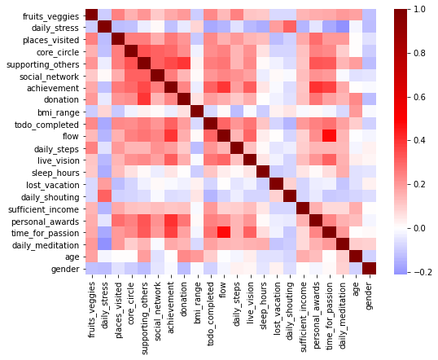

```python
# Heatmap correlations

fig, ax = plt.subplots(figsize=(8,6))

sns.heatmap(data.corr(), xticklabels=True, yticklabels=True, ax=ax, center=0, cmap='seismic') #see "diverging colormaps"
```

**Negative correlations:**

**Poor correlations**

- Variables like *bmi_range, sleep hours, lost vacation* and *daily shouting* seems to be poorly correlated with the others, or slightly negative. For example, pairs like *bmi range* and *daily steps*, *daily shouting* and *to-do completed*, *lost vacation* and *places visited* are slightly negative as we might expect.

**Positive correlations:**

- The rest of the variables are in general positively correlated with the others and these positive correlation are the strongest ones. From numerical analysis I saw *achievement* and *supporting others* are the variables positively correlated with the the greatest number of the others. In particular, achievement is the variable that are positively correlated with a greater number of other variables. For a predictive model, we found that flow and personal awards could be good predictive variables, as they are not too correlated between them. We could try only with these two, but we can include core circle and social network in case we want more than two. However, it would probably increase model complexity unnecessarily and therefore overfitting.

  Other not surprising strong correlations like:
  - *time for passion* with *flow*
  - *supporting others* with *donation*
  - *achievemnt* with *flow* and *personal awards*

```python
sorted_corr = np.unique(np.sort(data.corr().values.flatten()))[::-1] #Correlations in descendent order
array2D_corr = np.array(data.corr())

n = 12
nth_highest = sorted_corr[:n]
```

```python
nth_highest
```

```
array([1.        , 0.48263733, 0.40032959, 0.39420465, 0.38972744,
       0.37395656, 0.35900949, 0.33862994, 0.33363161, 0.32281997,
       0.3164962 , 0.31128491])
```

```python
for col in data.corr().columns:
    df_pos_corr = pd.DataFrame(data.corr()[col].nlargest(2)[1:]).transpose()
    df_neg_corr = pd.DataFrame(data.corr()[col].nsmallest(1)).transpose()
    df = pd.concat([df_pos_corr, df_neg_corr], axis=1)
    display(df)
```

|  | places_visited | gender |
| --- | --- | --- |
| fruits_veggies | 0.24852 | -0.118868 |

|  | daily_shouting | daily_meditation |
| --- | --- | --- |
| daily_stress | 0.309264 | -0.213672 |

|  | personal_awards | daily_stress |
| --- | --- | --- |
| places_visited | 0.279604 | -0.131707 |

|  | supporting_others | daily_stress |
| --- | --- | --- |
| core_circle | 0.33863 | -0.115973 |

|  | donation | gender |
| --- | --- | --- |
| supporting_others | 0.394205 | -0.131287 |

|  | supporting_others | age |
| --- | --- | --- |
| social_network | 0.311285 | -0.058707 |

|  | personal_awards | daily_stress |
| --- | --- | --- |
| achievement | 0.40033 | -0.120786 |

|  | supporting_others | gender |
| --- | --- | --- |
| donation | 0.394205 | -0.129959 |

|  | age | daily_steps |
| --- | --- | --- |
| bmi_range | 0.200395 | -0.128937 |

|  | achievement | daily_stress |
| --- | --- | --- |
| todo_completed | 0.309286 | -0.166975 |

|  | time_for_passion | daily_stress |
| --- | --- | --- |
| flow | 0.482637 | -0.142187 |

|  | fruits_veggies | bmi_range |
| --- | --- | --- |
| daily_steps | 0.243607 | -0.128937 |

|  | achievement | daily_stress |
| --- | --- | --- |
| live_vision | 0.316496 | -0.135016 |

|  | daily_meditation | daily_stress |
| --- | --- | --- |
| sleep_hours | 0.164169 | -0.152862 |

|  | daily_stress | places_visited |
| --- | --- | --- |
| lost_vacation | 0.192353 | -0.124751 |

|  | daily_stress | todo_completed |
| --- | --- | --- |
| daily_shouting | 0.309264 | -0.145587 |

|  | todo_completed | daily_stress |
| --- | --- | --- |
| sufficient_income | 0.203476 | -0.144872 |

|  | achievement | daily_stress |
| --- | --- | --- |
| personal_awards | 0.40033 | -0.044362 |

|  | flow | daily_stress |
| --- | --- | --- |
| time_for_passion | 0.482637 | -0.161858 |

|  | places_visited | daily_stress |
| --- | --- | --- |
| daily_meditation | 0.203315 | -0.213672 |

|  | donation | gender |
| --- | --- | --- |
| age | 0.23321 | -0.089236 |

|  | daily_meditation | supporting_others |
| --- | --- | --- |
| gender | 0.09405 | -0.131287 |

**Positive correlations:**

The strongest correlations are positive. Let's see what are the pairs of variables with the highest correlation

```
Highest correlations:


fruits_veggies - fruits_veggies:
1.0

flow - time_for_passion:
0.4826373253512499

achievement - personal_awards:
0.40032959107956373

supporting_others - donation:
0.39420465220667267

achievement - flow:
0.38972743712470126

achievement - time_for_passion:
0.37395655829229923

supporting_others - achievement:
0.35900949207041805

core_circle - supporting_others:
0.33862994082240555

supporting_others - personal_awards:
0.33363160903780187

supporting_others - time_for_passion:
0.32281997227051246

achievement - live_vision:
0.31649619770451914

supporting_others - social_network:
0.3112849098938094

live_vision - time_for_passion:
0.31101500793287484

achievement - todo_completed:
0.30928570200317784

daily_stress - daily_shouting:
0.30926429602231414

core_circle - social_network:
0.3049413472087288

todo_completed - flow:
0.30214098153931707

flow - live_vision:
0.30004494164840867

core_circle - achievement:
0.29235878020232786

places_visited - personal_awards:
0.2796037154559053
```

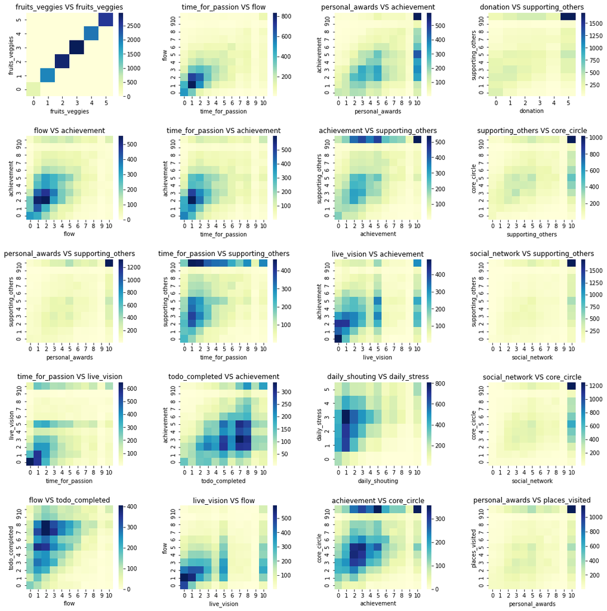

```python
# 12 Pairs of variables with the highest correlation

sorted_corr = np.unique(np.sort(data.corr().values.flatten()))[::-1] #Correlations in descendent order
array2D_corr = np.array(data.corr())

n = 20
nth_highest = sorted_corr[:n]

fig, axs = plt.subplots(5,4, figsize=(16,16))
fig.tight_layout(pad=5) #padding among subplots

axs = axs.flatten()
rows = []
columns = []
print("Highest correlations:\n\n")
for i in range(n):
    position = np.where(array2D_corr == nth_highest[i])
    row = data.corr().index[position[0][0]]
    column = data.corr().columns[position[1][0]]
    rows.append(row)
    columns.append(column)
    print("{} - {}:".format(row, column))
    print(nth_highest[i], "\n")
    frecuency = pd.crosstab(data[row],data[column]).iloc[::-1]
    ax = fig.sca(axs[i])
    ax.set(title='{} VS {}'.format(column,row))
    sns.heatmap(frecuency, ax=ax, cmap="YlGnBu")

    # axs[i].imshow(frecuency, cmap='Blues')
    # axs[i].hist2d(data[row],data[column], cmap='Blues')
```

```python
# Number of variables that each one is highly correlated with

rows_cols = rows + columns
for variable in list(set(rows_cols)):
    print(variable, rows_cols.count(variable))
```

```
live_vision 3
social_network 2
fruits_veggies 2
achievement 7
personal_awards 3
places_visited 1
time_for_passion 4
supporting_others 6
core_circle 3
daily_stress 1
daily_shouting 1
donation 1
flow 4
todo_completed 2
```

*achievement* and *supporting others* are the variables positively correlated with the the greatest number of the other.

#### Variable '*Achivement*':

Let's see the correlations of *achievement* with the others, and what pairs of these are less correlated between them:

```python
# Correlations with achievement
data.corr()['achievement'].sort_values(ascending=False)
```

```
achievement          1.000000
personal_awards      0.400330
flow                 0.389727
time_for_passion     0.373957
supporting_others    0.359009
live_vision          0.316496
todo_completed       0.309286
core_circle          0.292359
places_visited       0.264964
social_network       0.252225
donation             0.236727
daily_steps          0.193328
daily_meditation     0.172801
fruits_veggies       0.166643
sufficient_income    0.117023
sleep_hours          0.054920
age                  0.002239
gender              -0.006039
lost_vacation       -0.010751
bmi_range           -0.034303
daily_shouting      -0.066264
daily_stress        -0.120786
Name: achievement, dtype: float64
```

```python
# What pair of them are less correlated between them?
achievement_corrs = data.corr()['achievement'].sort_values().index.tolist()
data.corr()[achievement_corrs].loc[achievement_corrs]
```

|  | daily_stress | daily_shouting | bmi_range | lost_vacation | gender | age | sleep_hours | sufficient_income | fruits_veggies | daily_meditation | ... | social_network | places_visited | core_circle | todo_completed | live_vision | supporting_others | time_for_passion | flow | personal_awards | achievement |
| --- | --- | --- | --- | --- | --- | --- | --- | --- | --- | --- | --- | --- | --- | --- | --- | --- | --- | --- | --- | --- | --- |
| daily_stress | 1.000000 | 0.309264 | 0.084938 | 0.192353 | -0.128677 | -0.020649 | -0.152862 | -0.144872 | -0.095132 | -0.213672 | ... | 0.012720 | -0.131707 | -0.115973 | -0.166975 | -0.135016 | -0.035373 | -0.161858 | -0.142187 | -0.044362 | -0.120786 |
| daily_shouting | 0.309264 | 1.000000 | 0.054456 | 0.085184 | -0.064035 | -0.084847 | -0.078230 | -0.076268 | -0.071099 | -0.096076 | ... | -0.010305 | -0.089066 | -0.076232 | -0.145587 | -0.081179 | -0.064187 | -0.104970 | -0.080099 | -0.041729 | -0.066264 |
| bmi_range | 0.084938 | 0.054456 | 1.000000 | 0.032417 | -0.009803 | 0.200395 | -0.095543 | -0.014296 | -0.091937 | -0.070900 | ... | 0.017123 | -0.103696 | -0.025774 | -0.067473 | -0.009084 | 0.027601 | -0.023930 | 0.011586 | 0.016309 | -0.034303 |
| lost_vacation | 0.192353 | 0.085184 | 0.032417 | 1.000000 | 0.025472 | -0.052863 | -0.093058 | -0.083065 | -0.069845 | -0.113086 | ... | 0.011538 | -0.124751 | -0.083369 | -0.080262 | -0.028527 | -0.026155 | -0.026963 | 0.000539 | -0.038252 | -0.010751 |
| gender | -0.128677 | -0.064035 | -0.009803 | 0.025472 | 1.000000 | -0.089236 | -0.048616 | 0.006567 | -0.118868 | 0.094050 | ... | -0.050410 | -0.054253 | -0.096980 | -0.089833 | 0.022373 | -0.131287 | 0.015833 | -0.016699 | -0.020684 | -0.006039 |
| age | -0.020649 | -0.084847 | 0.200395 | -0.052863 | -0.089236 | 1.000000 | -0.056300 | 0.161993 | 0.183554 | 0.099682 | ... | -0.058707 | 0.003419 | 0.002869 | 0.096548 | 0.041089 | 0.190202 | 0.000118 | -0.002399 | 0.130737 | 0.002239 |
| sleep_hours | -0.152862 | -0.078230 | -0.095543 | -0.093058 | -0.048616 | -0.056300 | 1.000000 | 0.047208 | 0.105838 | 0.164169 | ... | -0.029174 | 0.129648 | 0.060685 | 0.117985 | 0.047949 | 0.013629 | 0.067811 | 0.036995 | 0.018537 | 0.054920 |
| sufficient_income | -0.144872 | -0.076268 | -0.014296 | -0.083065 | 0.006567 | 0.161993 | 0.047208 | 1.000000 | 0.151236 | 0.071580 | ... | 0.132226 | 0.173262 | 0.122687 | 0.203476 | 0.130777 | 0.115812 | 0.079585 | 0.086671 | 0.153977 | 0.117023 |
| fruits_veggies | -0.095132 | -0.071099 | -0.091937 | -0.069845 | -0.118868 | 0.183554 | 0.105838 | 0.151236 | 1.000000 | 0.195067 | ... | 0.105804 | 0.248520 | 0.153606 | 0.230350 | 0.113970 | 0.207907 | 0.171531 | 0.136223 | 0.165587 | 0.166643 |
| daily_meditation | -0.213672 | -0.096076 | -0.070900 | -0.113086 | 0.094050 | 0.099682 | 0.164169 | 0.071580 | 0.195067 | 1.000000 | ... | -0.006766 | 0.203315 | 0.103687 | 0.181956 | 0.152180 | 0.149154 | 0.196000 | 0.145943 | 0.154547 | 0.172801 |
| daily_steps | -0.057925 | -0.031981 | -0.128937 | -0.045349 | 0.032735 | -0.020511 | 0.010364 | 0.101667 | 0.243607 | 0.141684 | ... | 0.213596 | 0.196342 | 0.151113 | 0.204796 | 0.119280 | 0.145220 | 0.146962 | 0.143280 | 0.150016 | 0.193328 |
| donation | -0.038291 | -0.054656 | 0.059614 | -0.025449 | -0.129959 | 0.233210 | 0.005471 | 0.123999 | 0.200787 | 0.150520 | ... | 0.147615 | 0.212655 | 0.220173 | 0.189849 | 0.158218 | 0.394205 | 0.188767 | 0.162248 | 0.274397 | 0.236727 |
| social_network | 0.012720 | -0.010305 | 0.017123 | 0.011538 | -0.050410 | -0.058707 | -0.029174 | 0.132226 | 0.105804 | -0.006766 | ... | 1.000000 | 0.157615 | 0.304941 | 0.212253 | 0.184818 | 0.311285 | 0.202677 | 0.240043 | 0.214703 | 0.252225 |
| places_visited | -0.131707 | -0.089066 | -0.103696 | -0.124751 | -0.054253 | 0.003419 | 0.129648 | 0.173262 | 0.248520 | 0.203315 | ... | 0.157615 | 1.000000 | 0.259982 | 0.234049 | 0.149852 | 0.255008 | 0.198304 | 0.154917 | 0.279604 | 0.264964 |
| core_circle | -0.115973 | -0.076232 | -0.025774 | -0.083369 | -0.096980 | 0.002869 | 0.060685 | 0.122687 | 0.153606 | 0.103687 | ... | 0.304941 | 0.259982 | 1.000000 | 0.222466 | 0.216494 | 0.338630 | 0.227560 | 0.243300 | 0.250223 | 0.292359 |
| todo_completed | -0.166975 | -0.145587 | -0.067473 | -0.080262 | -0.089833 | 0.096548 | 0.117985 | 0.203476 | 0.230350 | 0.181956 | ... | 0.212253 | 0.234049 | 0.222466 | 1.000000 | 0.271881 | 0.252200 | 0.278042 | 0.302141 | 0.249857 | 0.309286 |
| live_vision | -0.135016 | -0.081179 | -0.009084 | -0.028527 | 0.022373 | 0.041089 | 0.047949 | 0.130777 | 0.113970 | 0.152180 | ... | 0.184818 | 0.149852 | 0.216494 | 0.271881 | 1.000000 | 0.233593 | 0.311015 | 0.300045 | 0.206593 | 0.316496 |
| supporting_others | -0.035373 | -0.064187 | 0.027601 | -0.026155 | -0.131287 | 0.190202 | 0.013629 | 0.115812 | 0.207907 | 0.149154 | ... | 0.311285 | 0.255008 | 0.338630 | 0.252200 | 0.233593 | 1.000000 | 0.322820 | 0.266881 | 0.333632 | 0.359009 |
| time_for_passion | -0.161858 | -0.104970 | -0.023930 | -0.026963 | 0.015833 | 0.000118 | 0.067811 | 0.079585 | 0.171531 | 0.196000 | ... | 0.202677 | 0.198304 | 0.227560 | 0.278042 | 0.311015 | 0.322820 | 1.000000 | 0.482637 | 0.239808 | 0.373957 |
| flow | -0.142187 | -0.080099 | 0.011586 | 0.000539 | -0.016699 | -0.002399 | 0.036995 | 0.086671 | 0.136223 | 0.145943 | ... | 0.240043 | 0.154917 | 0.243300 | 0.302141 | 0.300045 | 0.266881 | 0.482637 | 1.000000 | 0.217978 | 0.389727 |
| personal_awards | -0.044362 | -0.041729 | 0.016309 | -0.038252 | -0.020684 | 0.130737 | 0.018537 | 0.153977 | 0.165587 | 0.154547 | ... | 0.214703 | 0.279604 | 0.250223 | 0.249857 | 0.206593 | 0.333632 | 0.239808 | 0.217978 | 1.000000 | 0.400330 |
| achievement | -0.120786 | -0.066264 | -0.034303 | -0.010751 | -0.006039 | 0.002239 | 0.054920 | 0.117023 | 0.166643 | 0.172801 | ... | 0.252225 | 0.264964 | 0.292359 | 0.309286 | 0.316496 | 0.359009 | 0.373957 | 0.389727 | 0.400330 | 1.000000 |

22 rows × 22 columns

The more down and right, the most correlation the variables are with achievement. For a prediction model, we are interested in predictive variables with a low correlation between them, so we should look for small values in the down-right part of this dataframe. We see a 0.217978 corresponding to *flow* and *personal awards*, so it might be a good option chosing only these two. *core circle* and *social network* would be the next ones to chose in case we want more.

```python
# The lowest values of correlation in absolute value
np.unique(np.sort(np.array(abs(data.corr()[achievement_corrs[11:]].loc[achievement_corrs[11:]])).flatten()))
```

```
array([0.14761525, 0.14985247, 0.15491703, 0.15761513, 0.15821833,
       0.16224798, 0.18481764, 0.18876745, 0.18984902, 0.19830437,
       0.20267701, 0.20659311, 0.21225279, 0.21265549, 0.21470312,
       0.21649415, 0.21797815, 0.22017343, 0.22246642, 0.22756044,
       0.23359329, 0.23404912, 0.23672727, 0.23980767, 0.24004297,
       0.24329982, 0.2498565 , 0.25022277, 0.25219994, 0.25222473,
       0.25500816, 0.25998208, 0.26496444, 0.26688059, 0.271881  ,
       0.27439719, 0.27804196, 0.27960372, 0.29235878, 0.30004494,
       0.30214098, 0.30494135, 0.3092857 , 0.31101501, 0.31128491,
       0.3164962 , 0.32281997, 0.33363161, 0.33862994, 0.35900949,
       0.37395656, 0.38972744, 0.39420465, 0.40032959, 0.48263733,
       1.        ])
```

**Negative correlations:**

Let's see de most negative correlated variables with the others:

```
Lowest correlations:


daily_stress - daily_meditation:
-0.21367242460175634

daily_stress - todo_completed:
-0.16697526420745487

daily_stress - time_for_passion:
-0.1618577321177887

daily_stress - sleep_hours:
-0.15286158450655735

todo_completed - daily_shouting:
-0.14558711896131799

daily_stress - sufficient_income:
-0.14487168163684583

daily_stress - flow:
-0.142187370687171

daily_stress - live_vision:
-0.1350155981795351

daily_stress - places_visited:
-0.13170694011317127

supporting_others - gender:
-0.13128712907783338

donation - gender:
-0.12995859803876536

bmi_range - daily_steps:
-0.1289368441372705

daily_stress - gender:
-0.128676852685506

places_visited - lost_vacation:
-0.12475119803990595

daily_stress - achievement:
-0.12078578179755883

fruits_veggies - gender:
-0.11886752387580067

daily_stress - core_circle:
-0.11597261409797491

lost_vacation - daily_meditation:
-0.11308591354343855

daily_shouting - time_for_passion:
-0.10497038387085024

places_visited - bmi_range:
-0.10369634596618633
```

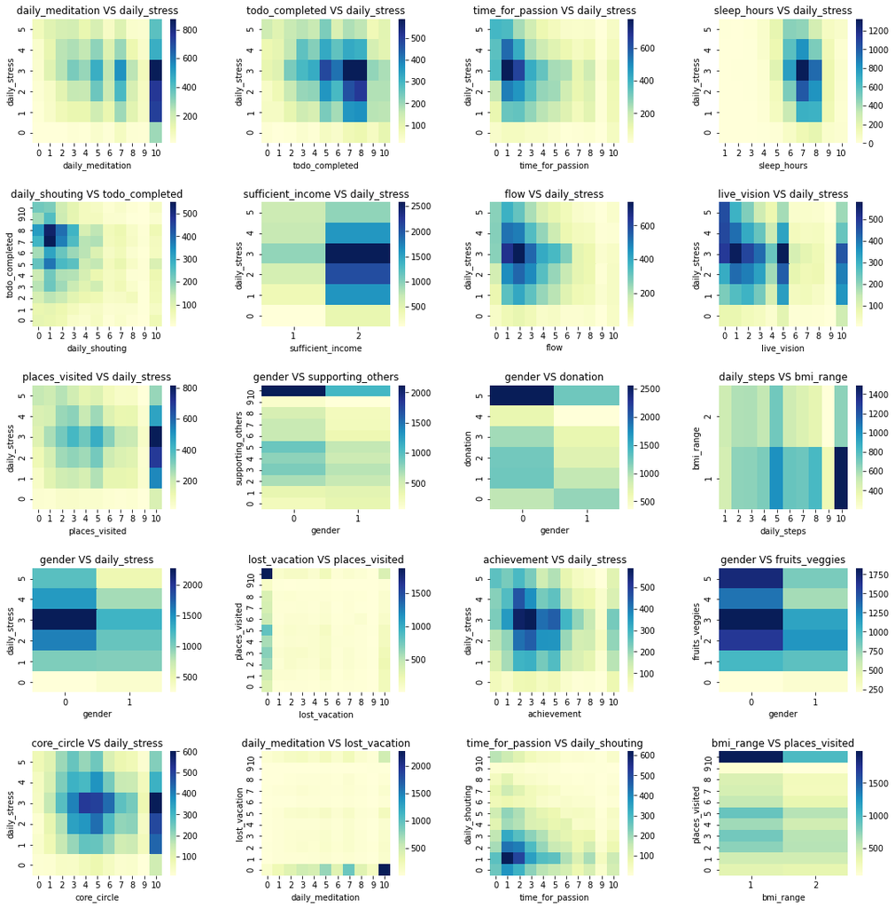

```python
# 12 Pairs of variables with the most negative correlation

sorted_corr = np.unique(np.sort(data.corr().values.flatten()))
array2D_corr = np.array(data.corr())

n = 20
nth_lowest = sorted_corr[:n]

fig, axs = plt.subplots(5,4, figsize=(16,16))
fig.tight_layout(pad=5) #padding between subplots

axs = axs.flatten()
rows = []
columns = []
print("Lowest correlations:\n\n")
for i in range(n):
    position = np.where(array2D_corr == nth_lowest[i])
    row = data.corr().index[position[0][0]]
    column = data.corr().columns[position[1][0]]
    rows.append(row)
    columns.append(column)
    print("{} - {}:".format(row, column))
    print(nth_lowest[i], "\n")
    frecuency = pd.crosstab(data[row],data[column]).iloc[::-1]
    ax = fig.sca(axs[i])
    ax.set(title='{} VS {}'.format(column,row))
    sns.heatmap(frecuency, ax=ax, cmap="YlGnBu")

    # axs[i].imshow(frecuency, cmap='Blues')
    # axs[i].hist2d(data[row],data[column], cmap='Blues')
```

```python
# Number of the other variables that each one is highly negative correlated with

rows_cols = rows + columns
for variable in list(set(rows_cols)):
    print(variable, rows_cols.count(variable))
```

```
places_visited 3
core_circle 1
daily_shouting 2
bmi_range 2
flow 1
sufficient_income 1
live_vision 1
time_for_passion 2
supporting_others 1
daily_stress 11
sleep_hours 1
daily_meditation 2
gender 4
lost_vacation 2
fruits_veggies 1
achievement 1
daily_steps 1
donation 1
todo_completed 2
```

#### Variable *'daily stress'*

As we showed above in the heatmap of the correlations matrix, *daily stress* is negatively correlated with a number of other variables. Let's see the most negative correlations of *daily stress* with the others, and what pairs of these others are less correlated between them:

```python
# Correlations with daily stress
data.corr()['daily_stress'].sort_values()
```

```
daily_meditation    -0.213672
todo_completed      -0.166975
time_for_passion    -0.161858
sleep_hours         -0.152862
sufficient_income   -0.144872
flow                -0.142187
live_vision         -0.135016
places_visited      -0.131707
gender              -0.128677
achievement         -0.120786
core_circle         -0.115973
fruits_veggies      -0.095132
daily_steps         -0.057925
personal_awards     -0.044362
donation            -0.038291
supporting_others   -0.035373
age                 -0.020649
social_network       0.012720
bmi_range            0.084938
lost_vacation        0.192353
daily_shouting       0.309264
daily_stress         1.000000
Name: daily_stress, dtype: float64
```

```python
# What pair of them are less correlated between them?
stress_corrs = abs(data.corr()['daily_stress']).sort_values().index.tolist()
data.corr()[stress_corrs[11:]].loc[stress_corrs[11:]]
```

|  | places_visited | live_vision | flow | sufficient_income | sleep_hours | time_for_passion | todo_completed | lost_vacation | daily_meditation | daily_shouting | daily_stress |
| --- | --- | --- | --- | --- | --- | --- | --- | --- | --- | --- | --- |
| places_visited | 1.000000 | 0.149852 | 0.154917 | 0.173262 | 0.129648 | 0.198304 | 0.234049 | -0.124751 | 0.203315 | -0.089066 | -0.131707 |
| live_vision | 0.149852 | 1.000000 | 0.300045 | 0.130777 | 0.047949 | 0.311015 | 0.271881 | -0.028527 | 0.152180 | -0.081179 | -0.135016 |
| flow | 0.154917 | 0.300045 | 1.000000 | 0.086671 | 0.036995 | 0.482637 | 0.302141 | 0.000539 | 0.145943 | -0.080099 | -0.142187 |
| sufficient_income | 0.173262 | 0.130777 | 0.086671 | 1.000000 | 0.047208 | 0.079585 | 0.203476 | -0.083065 | 0.071580 | -0.076268 | -0.144872 |
| sleep_hours | 0.129648 | 0.047949 | 0.036995 | 0.047208 | 1.000000 | 0.067811 | 0.117985 | -0.093058 | 0.164169 | -0.078230 | -0.152862 |
| time_for_passion | 0.198304 | 0.311015 | 0.482637 | 0.079585 | 0.067811 | 1.000000 | 0.278042 | -0.026963 | 0.196000 | -0.104970 | -0.161858 |
| todo_completed | 0.234049 | 0.271881 | 0.302141 | 0.203476 | 0.117985 | 0.278042 | 1.000000 | -0.080262 | 0.181956 | -0.145587 | -0.166975 |
| lost_vacation | -0.124751 | -0.028527 | 0.000539 | -0.083065 | -0.093058 | -0.026963 | -0.080262 | 1.000000 | -0.113086 | 0.085184 | 0.192353 |
| daily_meditation | 0.203315 | 0.152180 | 0.145943 | 0.071580 | 0.164169 | 0.196000 | 0.181956 | -0.113086 | 1.000000 | -0.096076 | -0.213672 |
| daily_shouting | -0.089066 | -0.081179 | -0.080099 | -0.076268 | -0.078230 | -0.104970 | -0.145587 | 0.085184 | -0.096076 | 1.000000 | 0.309264 |
| daily_stress | -0.131707 | -0.135016 | -0.142187 | -0.144872 | -0.152862 | -0.161858 | -0.166975 | 0.192353 | -0.213672 | 0.309264 | 1.000000 |

The more down and right, the most correlation the variables are with *daily stress*. For a prediction model, we are interested in predictive variables with a low correlation (in absolute value) between them, so we should look for small values in the down-right part of this dataframe. We see a -0.096076 corresponding to *daily shouting* and *daily meditation*, so it might be a good option chosing these two. Other ones we can chose that are poorly correlated with *daily shouting* and *daily meditation* are *lost vacation* and *sufficient income*.

```python
# The lowest values of correlation in absolute value
np.unique(np.sort(np.array(abs(data.corr()[stress_corrs[11:]].loc[stress_corrs[11:]])).flatten()))
```

```
array([5.39244520e-04, 2.69626501e-02, 2.85272804e-02, 3.69947788e-02,
       4.72083003e-02, 4.79493603e-02, 6.78111005e-02, 7.15803146e-02,
       7.62676096e-02, 7.82295707e-02, 7.95853327e-02, 8.00993712e-02,
       8.02622588e-02, 8.11793283e-02, 8.30652481e-02, 8.51840221e-02,
       8.66714470e-02, 8.90661821e-02, 9.30579567e-02, 9.60761312e-02,
       1.04970384e-01, 1.13085914e-01, 1.17985233e-01, 1.24751198e-01,
       1.29647517e-01, 1.30777052e-01, 1.31706940e-01, 1.35015598e-01,
       1.42187371e-01, 1.44871682e-01, 1.45587119e-01, 1.45942796e-01,
       1.49852474e-01, 1.52180100e-01, 1.52861585e-01, 1.54917034e-01,
       1.61857732e-01, 1.64169500e-01, 1.66975264e-01, 1.73262396e-01,
       1.81955930e-01, 1.92352962e-01, 1.96000331e-01, 1.98304373e-01,
       2.03315316e-01, 2.03476252e-01, 2.13672425e-01, 2.34049116e-01,
       2.71880996e-01, 2.78041959e-01, 3.00044942e-01, 3.02140982e-01,
       3.09264296e-01, 3.11015008e-01, 4.82637325e-01, 1.00000000e+00])
```

### 2.6 Summary of the EDA: Key Findings and insights

From the EDA we can conclude some key findings:

- About distribution of data, we see that variables are not normally distributed. Most of them are left-skewed, in particular those related to social area: *core circle, social network, supporting others or donation*. This means that there are a few people with a poor social life compared with the mayority's. On the other hand, other variables are right-skewed, so for example there are a few people standing out in *time for passion, flow and achievement* from the rest.
- There is a clear division between variables positively (red) and negatively (blue) correlated with the others in general. *achievement* and *daily stress* are the ones with a greater potencial to be predicted, as the have the strongest positive and negative correlations respectively.
- *achievement* is the variable that are positively correlated with a greater number of other variables. For a predictive model, we found that *flow* and *personal awards* could be good predictive variables, as they are not too correlated between them. We could try only with these two, but we can include *core circle* and *social network* in case we want more than two. However, it would probably increase model complexity unnecessarily and therefore overfitting.
- *daily stress* is the one with a greater number of negative correlations with other variables, such as daily meditation, to-do completed, time for passion or sleep hours. There might be a real influence of these variables in the level of stress people experience. For a predictive model, *daily shouting* and *daily meditation* could be good predictive variables. Other good options to include are *lost vacation*, although it doesn't seem to have much a real relationship with stress, and *sufficient income*.

## 3. Hypothesis

**Hypothsis 1:** *Population sleep less than 7 hours (World Health Organization recommendation is 7-8 hours)*. We can perform a t-test and check out if people sleep in average fewer hours than the OMS recommends, which might be indicative for a poor quality of life.The next step would be to see if those who sleep few hours also have negative indicators as a high levels of stress or low marks in achivement, personal awards, etc.

**Hypothesis 2:** *Data points with high values for positive attributes are grouped together*. It is said than one good habit positively affects in other areas, producing a kind of "virtuous cycle". Because of this and the similar behaviours of positive attributes (reds in the correlation matrix) we saw with the other variables, we might expect data to be grouped by positive and negative attributes. We could perform clusttering or classification algorithms along with a significance test of the results to check out this hypothesis.

**Hypothesis 3:** *There is a correlation between* achievement *and the variables* flow*,* daily_meditation *and* time for passion *significantly different from zero.* If so, we can try a predictive model like a linear model to predict achievement or just use the findings for interpretation and increase of our achievements.

### Significance test for the hypothsis 1: Population sleep less than 7 hours

We assume that the sleep hours follow a normal distribution and we are going to process the variable as continuous, although our data only takes integers between 1 and 10. Our null ($H_{0}$) and alternative ($H_{1}$) hypothesis are:

$H_{0}: \mu < 7h$  
$H_{1}: \mu \geq 7h$

The population standard deviation is unknown, so we are going to estimate it from our data and perform a t test:

**1.** We calculate the t statistic:

$t_0 = \large \frac{\overline{X} - \mu}{\Large \frac{S} {\sqrt n}} \hspace{0.5cm} \small [1]$

where,

$S = \large \sqrt{\frac{\sum_{i=1}^n (x_{i}-\overline x)^2}{n-1}}$

is the standar deviation of our sample, and

$\mu$: population mean  
$\overline X$: sample mean

**2.** The p-value is the probability of $t$ to be greater than what we got from our sample, $t_0$. This is the area down the curve of the T-Student distribution, whose expression is:

$f(t) = \large \frac{\Gamma(\frac{\Large \nu + 1}{2})}{\sqrt{\nu\pi}\hspace{1mm} \Gamma(\nu/2)} (1+\frac{t^2}{\nu})^{-\frac{\nu+1}{2}} \hspace{0.5cm} \small [2]$,

where

$\hspace{2cm}\Gamma(p) = \int_0^\infty x^{p-1}e^{-x}dx \hspace{0.5cm} \small [3]$

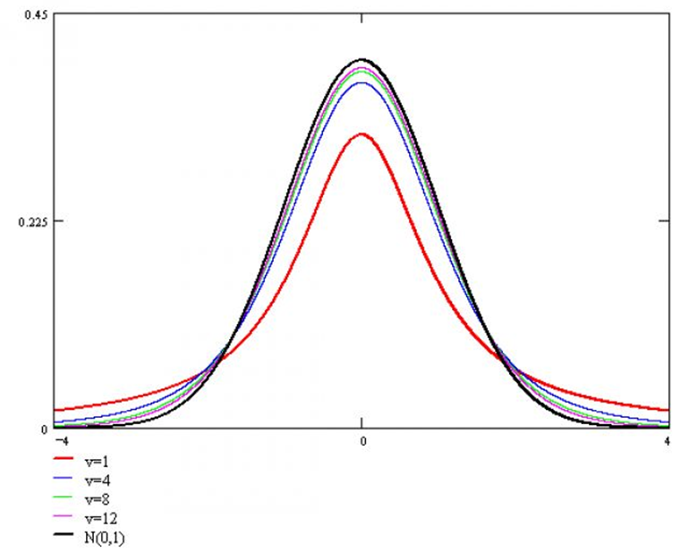

The area down the curve is the integral of $f(t)$ between 2 t's. When integrating between $t_0$ and $\infty$ we get the p-value, which is the probability of t > $t_0$, and therefore, the probability of the mean from another sample to be greater than our $\overline X$.

*What is the probability of the population mean to be less than 7h, giving our sample?*  
See in [0] that for the variable t, keeping $\mu$ fixed and varying $\overline X$ is equivalent to keeping a $\overline X$ and varying $\mu$. To calculate the probability of the population mean to be less than 7h giving our sample, we would have our $\overline X$ fixed (from our sample) and we would traverse (recorreríamos) $\mu$ from $7 \rightarrow -\infty$ (to 0 actually), which is the same as keeping $\mu = 7$ and traverse $\overline X$ from $7.03 \rightarrow \infty$. When integrating $f(t)$ we would traverse t in opposite directions, but we can see in [0] that also $dt$ has opposite sign, so the integral result would be the same.

Thus, *the probability of population mean to be less than 7h giving our sample, is exactly the same as the probability of any sample mean to be greater than ours (7.03h) assuming the hypothesis that the population mean is 7h, i.e., giving $\mu = 7$*

```python
from scipy.stats import t

mu = 7 # Population mean if the hypothesis is true
sample_mean = data['sleep_hours'].mean()
sample_std = data['sleep_hours'].std()
n = data['sleep_hours'].shape[0]

t_stat = (sample_mean - mu) / (sample_std/np.sqrt(n))
t_stat
```

```
3.3069605551230157
```

```python
# Probability of mu < 7h

p_value = 1-t.cdf(t_stat, df=n-1)
print("p-value: ", p_value)
print("1-p-pavlue: ", 1-p_value)
```

```
p-value:  0.0004728744186621725
1-p-pavlue:  0.9995271255813378
```

My confidence level was 99%, so p-values below 0.01 would lead us to reject the null hypothesis. I obtained a $p-value \approx 0.0005$. *We can reject the null hypothesis with (at least) a 99% of confidence*

*$H_{1}$ accepted: Population sleep in average 7h or more*

**Extra: Bayesian interpretation**

NOTE: I think expressions below are not valid for continuous variables, so this can be all wrong

Define:

$r = \large \frac{p(H_{0}|x)}{p(H_{1}|x)} = \frac{p(H_{0})·p(x|H_{0})}{p(H_{1})·p(x|H_{1})} = \frac{p(H_{0})}{p(H_{1})}·\frac{p_{value}}{1 - p_{value}}$,

```python
# Giving the same prior probabilities to both hypothesis, p(H0) = p(H1):

r = p_value/(1-p_value)
r
```

```
0.00047309813466757356
```

```python
1/r
```

```
2113.726363987164
```

The alternative hypothesis is 2114 times more likely than the null hypothesis. The sum of both probabilities is 1, so:

```python
p_H1 = (1/r) / ((1/r)+1)
p_H1
```

```
0.9995271255813378
```

Posterior probability: $p(H_{1}) = 99.95 \% $

**Which is the value of the population mean?**

```python
mu = 7.03
t_stat = (sample_mean - mu) / (sample_std/np.sqrt(n))
t_stat
```

```
0.48867891499420146
```

```python
t.cdf(t_stat, df=n-1)
```

```
0.6874612820197958
```

$\mu = \overline{X} \pm \large t·\frac{S}{\sqrt{n}} \$

```python
t.ppf(0.95, df=n-1) * sample_std/math.sqrt(n)
```

```
0.01751038383904761
```

**The mean is $(7.03 \pm 0.02)h$ with a confidence level of 95%**

## 4. Next steps

The steps may be:

- Create a linear model for stress level with *daily meditation* and *daily shouting* as predictive variables, and see if they really have a correlation significantly different from zero. We can try a log transformation in case we don't get normally distributed residuals, as the variable *daily shouting* is right-skewed and this can lead to skewed residuals. With *daily mediatation* a polynomial transformation might be required to fix the left skew.
- Create a predictive model for *achievement* with *flow* and *personal awards* as predictive variables, and see if they really have a correlation significantly different from zero. Again, we can try a log transformation with the variable *flow* in case we don't get normally distributed residuals, as it is right-skewed, and we can also try polynomial transformation with *personal awards*.
- Look for clustters to see the disposition of the data. We could perform clusttering or classification algorithms to prove hypothesis 2. Scaling the variables may be necessary to this issue related with distances.

## 5. Linear Regression for *daily stress*

Correlations Pearson coefficients, r, gave us the idea of how well the linear model model fit to data, but it doesn't say anything about how much the variable influence on stress. Thus, the magnitude of linear regression coefficients and the Pearson correlations have nothing to do and they don't to be related necessarily. What tell us about what features influence the most on stress is the magnitude of linear regression coefficient.

Now we are going to perform some linear regression models, focusing on the interpretation of what are the main factors that cause *daily stress*, so we'll see what are features with the strongest influence by comparing the corresponding coeficients. These ones can probabily be sources of stress and thus the findings may be of great interest.

```python
from sklearn.model_selection import train_test_split, cross_val_score, cross_val_predict, GridSearchCV
from sklearn.linear_model import LinearRegression, Lasso, Ridge, ElasticNet, LassoCV, RidgeCV, ElasticNetCV
from sklearn.preprocessing import PolynomialFeatures, StandardScaler
from sklearn.pipeline import Pipeline
from sklearn.feature_selection import RFE
from sklearn.metrics import r2_score, mean_squared_error
```

First we'll remove the variable *timestamp* as we are not interested in this, and *bmi_range* as the values are 1 or 2, so they should be wrong ("body mass index" has typical values of 18 - 30)

```python
data_original = data.copy()
data = data.drop(['timestamp', 'bmi_range'], axis=1)
```

### 5.1 Simple Linear Regression with `OLS` from `statsmodels.api`

Firsty, we will perform a linear model with the class `OLS` (Ordinary Linear Squares) from `statsmodel.api`, which provide us a more statistical treatment, as for example the t value from a significance test to accept the no-null value of the coefficients. We will pass to the OLS object the training sets X_train and y_train. We will do the trin-test split with a test size of 0.3 (30%), which result in 8928 data points for the training set and 3827 for the test set. We choose a seed for convinience, for example random_state=2021, to ensure the splits are the same when comparing with other models. Once we have a baseline, we will try adding regularization and polynomial features and prove if they shed light on what factors have more impact on stress

```python
# Baseline

import statsmodels.api as sm

y = data['daily_stress']
X = data.drop('daily_stress', axis=1)
X_train, X_test, y_train, y_test = train_test_split(X,y,test_size=0.3, random_state=2021)

lr = sm.OLS(y_train, sm.add_constant(X_train))
OLSresults = lr.fit()

print("R2 on training set:", r2_score(y_train, OLSresults.predict(sm.add_constant(X_train))))
print("R2 on test set:", r2_score(y_test, OLSresults.predict(sm.add_constant(X_test))))
rmse = np.sqrt(mean_squared_error(y_test, OLSresults.predict(sm.add_constant(X_test))))
print("Root mean squared error: ", rmse)

display(OLSresults.summary())
```

```
R2 on training set: 0.20751448027951147
R2 on test set: 0.19640373519899001
Root mean squared error:  1.2239315195417808
```

OLS Regression Results

| Dep. Variable: | daily_stress | R-squared: | 0.208 |
| --- | --- | --- | --- |
| Model: | OLS | Adj. R-squared: | 0.206 |
| Method: | Least Squares | F-statistic: | 116.6 |
| Date: | Sun, 18 Apr 2021 | Prob (F-statistic): | 0.00 |
| Time: | 12:05:44 | Log-Likelihood: | -14475. |
| No. Observations: | 8928 | AIC: | 2.899e+04 |
| Df Residuals: | 8907 | BIC: | 2.914e+04 |
| Df Model: | 20 |  |  |
| Covariance Type: | nonrobust |  |  |

|  | coef | std err | t | P>\|t\| | [0.025 | 0.975] |
| --- | --- | --- | --- | --- | --- | --- |
| const | 4.1133 | 0.105 | 39.351 | 0.000 | 3.908 | 4.318 |
| fruits_veggies | -0.0194 | 0.010 | -1.955 | 0.051 | -0.039 | 5.48e-05 |
| places_visited | -0.0124 | 0.004 | -2.777 | 0.006 | -0.021 | -0.004 |
| core_circle | -0.0234 | 0.005 | -4.515 | 0.000 | -0.034 | -0.013 |
| supporting_others | 0.0192 | 0.005 | 3.879 | 0.000 | 0.009 | 0.029 |
| social_network | 0.0234 | 0.005 | 4.933 | 0.000 | 0.014 | 0.033 |
| achievement | -0.0167 | 0.006 | -2.852 | 0.004 | -0.028 | -0.005 |
| donation | -0.0009 | 0.008 | -0.112 | 0.910 | -0.016 | 0.015 |
| todo_completed | -0.0233 | 0.006 | -4.060 | 0.000 | -0.034 | -0.012 |
| flow | -0.0296 | 0.007 | -4.383 | 0.000 | -0.043 | -0.016 |
| daily_steps | 0.0042 | 0.005 | 0.862 | 0.388 | -0.005 | 0.014 |
| live_vision | -0.0155 | 0.004 | -3.498 | 0.000 | -0.024 | -0.007 |
| sleep_hours | -0.0959 | 0.011 | -8.602 | 0.000 | -0.118 | -0.074 |
| lost_vacation | 0.0487 | 0.004 | 13.530 | 0.000 | 0.042 | 0.056 |
| daily_shouting | 0.1253 | 0.005 | 25.168 | 0.000 | 0.116 | 0.135 |
| sufficient_income | -0.2563 | 0.031 | -8.346 | 0.000 | -0.317 | -0.196 |
| personal_awards | 0.0224 | 0.005 | 4.641 | 0.000 | 0.013 | 0.032 |
| time_for_passion | -0.0328 | 0.006 | -5.658 | 0.000 | -0.044 | -0.021 |
| daily_meditation | -0.0488 | 0.005 | -10.535 | 0.000 | -0.058 | -0.040 |
| age | 0.0210 | 0.015 | 1.420 | 0.156 | -0.008 | 0.050 |
| gender | -0.3315 | 0.028 | -11.950 | 0.000 | -0.386 | -0.277 |

| Omnibus: | 103.262 | Durbin-Watson: | 1.990 |
| --- | --- | --- | --- |
| Prob(Omnibus): | 0.000 | Jarque-Bera (JB): | 64.643 |
| Skew: | -0.030 | Prob(JB): | 9.18e-15 |
| Kurtosis: | 2.588 | Cond. No. | 169. |

Warnings:  
[1] Standard Errors assume that the covariance matrix of the errors is correctly specified.

```python
rmse_cv_ols = np.sqrt(mean_squared_error(y, cross_val_predict(LinearRegression(), X, y)))
print(rmse_cv_ols)
```

```
1.2263339068499821
```

Features with coefficients significantly different from 0 are shown next. Let's choose a 99% of confidence level as criteria (p-value < 0.01), so we will keep features where the column "P<|t|" is less that 0.01":

```python
features_nonzero = X.columns.drop(['fruits_veggies','donation', 'daily_steps', 'age'])
X_train2 = sm.add_constant(X_train[features_nonzero])
X_test2 = sm.add_constant(X_test[features_nonzero])

lr2 = sm.OLS(y_train, X_train2)
OLSresults2 = lr2.fit() #OLSResults object

print("R2 on training set:", r2_score(y_train, OLSresults2.predict(X_train2)))
print("R2 on test set:", r2_score(y_test, OLSresults2.predict(X_test2)))
rmse = np.sqrt(mean_squared_error(y_test, OLSresults2.predict(X_test2)))
print("Root mean squared error: ", rmse)

coefs2 = OLSresults2.params.sort_values()
print("-"*50)
print("\nCoefficients: \n")
print(coefs2)

rmse_cv_ols2 = np.sqrt(mean_squared_error(y, cross_val_predict(LinearRegression(), X[features_nonzero], y)))
print("\nRmse CV: ", rmse_cv_ols2)
```

```
R2 on training set: 0.2070379500456585
R2 on test set: 0.19625620857542925
Root mean squared error:  1.224043860904083
--------------------------------------------------

Coefficients:

gender              -0.327591
sufficient_income   -0.253618
sleep_hours         -0.098262
daily_meditation    -0.048974
time_for_passion    -0.033616
flow                -0.029732
core_circle         -0.023774
todo_completed      -0.023402
achievement         -0.016938
live_vision         -0.015428
places_visited      -0.013766
supporting_others    0.019710
personal_awards      0.022859
social_network       0.023035
lost_vacation        0.048548
daily_shouting       0.125046
const                4.135555
dtype: float64

Rmse CV:  1.2260816886645598
```

These coefficients are significantly different from zero*. Variables *gender, sufficient income* and *daily shouting* (postive coefficient) seems to be the ones with more influence on stress.

\*Note: Residuals are not normally distributed and there is no way to apply any data transformation (log, root, boxcox) that get a more normally-distributed residuals. As significance tests performed by `statsmodel.api.OLS` assume normally distributed residuals, we should be prudent and critical with the results before reaching a conclusion. However, one fact in favour is that independency $\chi^2$ tests show a dependency between the categories of *stress* and, at least, the variables *gender, sufficient income* and *daily shouting*. These ensure just dependency between unordered categories, not correlation, but giving a look to data, it is noticeable that this dependency follows a definited direction. Evaluations points to significant no-null correlations. See the Statistical Hypothesis Testing for dependencies and correlations for details.

We have a number of features, but some of them are close to zero. We can try now **reducing the number of features** a see what coefficients we obtain for the remaining ones. We will do this by 2 approaches: `Lasso` Regression and `RFE` (Recursive Features Elimination):

### 5.2 Reducing features: Lasso

We see some features that stand out against the others: gender, sufficient income and daily shouting. However, we didn't obtain a great 𝑅2 score, so it might not be significantly different from zero. We can't be sure for now whether there is a real relation between those variables and stress.

We can try simplifying the model by adding regularization and see if we obtain a better fit that make us have more confidence in the real influence of the predictive features. For this purpose, Lasso is usually a better choice than Ridge in terms of interpretation, as some cofficients are more likely to vanish with Lasso, keeping only those with a stronger impact in the output variable and improving interpretation of this simplified model. In addition, we tried with an ElasticNetCV and obtained that the best l1_ratio parameter was 1, so we will set different alpha values for a Lasso Regression. So we will create a Lasso model using LassoCV in order to try with some different alpha values, the parameter with which we control the regularization amount, and compare the resulting models through the 𝑅2 score obtained after doing Cross Validation to ensure the particular selection of the training-validation split doesn't affect to determine which one is better. We keep the parameter *cv=None* that use the default 5-fold cross validation and we use the *X_train* subset used previously with LinearRegression, which will be the one that, in turn, will be splitted in 5 folds to perform the Cross Validation. We are keeping the X_test to check the performance to unseen data.

```python
alphas = np.geomspace(1e-5, 1, num=24)
lassoCV = LassoCV(alphas=alphas)
lassoCV.fit(X_train, y_train)

print("Best model:\n")
print("Alpha: ", lassoCV.alpha_)
print("R2 on test set: ", lassoCV.score(X_test, y_test))  #r2_score(y_test, lassoCV.predict(X_test))
rmse = np.sqrt(mean_squared_error(y_test, lassoCV.predict(X_test)))
print("Root mean squared error: ", rmse)
```

```
Best model:

Alpha:  0.0014924955450518291
R2 on test set:  0.1964983336215841
Root mean squared error:  1.223859477520299
```

```python
rmse_cv_lasso = np.sqrt(mean_squared_error(y, cross_val_predict(Lasso(alpha=lassoCV.alpha_), X, y)))
print(rmse_cv_lasso)
```

```
1.226344366252987
```

```python
pd.DataFrame(list(zip(X.columns, lassoCV.coef_)), columns=['feature','coef']).set_index('feature').sort_values(by='coef')
```

| feature | coef |
| --- | --- |
| gender | -0.324783 |
| sufficient_income | -0.248169 |
| sleep_hours | -0.095088 |
| daily_meditation | -0.048859 |
| time_for_passion | -0.032768 |
| flow | -0.029366 |
| core_circle | -0.023177 |
| todo_completed | -0.023167 |
| fruits_veggies | -0.018384 |
| achievement | -0.016536 |
| live_vision | -0.015557 |
| places_visited | -0.012463 |
| donation | -0.000072 |
| daily_steps | 0.003708 |
| age | 0.018553 |
| supporting_others | 0.019050 |
| personal_awards | 0.022077 |
| social_network | 0.023043 |
| lost_vacation | 0.048645 |
| daily_shouting | 0.125290 |

None of the coefficients have gotten null. In fact, results are very similar to the ones from plain linear regression, both the $R^2$ score and the coefficient values. However, trying with a higher regularization (more than alpha=1), $R^2$ score is practically null.

### 5.3 Reducing features: RFE

```python
rfe = RFE(LinearRegression(), n_features_to_select=12)
rfe.fit(X, y)

features = X.columns[rfe.support_]
features
```

```
Index(['core_circle', 'social_network', 'todo_completed', 'flow',
       'sleep_hours', 'lost_vacation', 'daily_shouting', 'sufficient_income',
       'time_for_passion', 'daily_meditation', 'age', 'gender'],
      dtype='object')
```

```python
X_train_rfe_1 = sm.add_constant(X_train[features])
X_test_rfe_1 = sm.add_constant(X_test[features])

lr_rfe = sm.OLS(y_train, X_train_rfe_1)
OLSresults_rfe = lr_rfe.fit() #OLSResults object

print("R2 on training set:", r2_score(y_train, OLSresults_rfe.predict(X_train_rfe_1)))
print("R2 on test set:", r2_score(y_test, OLSresults_rfe.predict(X_test_rfe_1)))
rmse = np.sqrt(mean_squared_error(y_test, OLSresults_rfe.predict(X_test_rfe_1)))
print("Root mean squared error: ", rmse)

coefs_rfe = OLSresults_rfe.params.sort_values()
print("-"*50)
print("Coefficients:\n")
print(coefs_rfe)
```

```
R2 on training set: 0.2018642122384604
R2 on test set: 0.19128926477826702
Root mean squared error:  1.2278201843907077
--------------------------------------------------
Coefficients:

gender              -0.336682
sufficient_income   -0.265136
sleep_hours         -0.101721
daily_meditation    -0.050159
time_for_passion    -0.033970
flow                -0.033181
todo_completed      -0.025641
core_circle         -0.022373
social_network       0.026723
age                  0.035751
lost_vacation        0.049624
daily_shouting       0.126775
const                4.161317
dtype: float64
```

```python
rmse_cv_rfe = np.sqrt(mean_squared_error(y, cross_val_predict(LinearRegression(), X[features], y)))
print(rmse_cv_rfe)
```

```
1.2294077096448424
```

There might be interactions between variables. Let's try adding Polynomial Features and see if we get a better perform:

### 5.4 Polynomial Features

We can drop *gender* to see the interactions between other, as it makes no so much sense to see the interaction terms with gender, and then perform polynomial features. *Daily_shouting* has negative correlations with the others, so we tried including ratio features like $\frac{meditation}{shouting}$ but no good results were obtained. Adding Polynomial Features might shed light on possible interactions between positively correlated variables.

Let's try polynomial features, keeping only the interaction terms, and creating a Lasso model feeding it with these new features:

```python
pf = PolynomialFeatures(degree=2, interaction_only=True)
X_train_poly = pf.fit_transform(X_train.drop('gender', axis=1))
X_test_poly = pf.transform(X_test.drop('gender', axis=1))
lassoCV_poly = LassoCV(alphas = alphas, max_iter=100000)
lassoCV_poly.fit(X_train_poly, y_train)

print("Best model with polynomial features:\n")
print("Alpha: ", lassoCV_poly.alpha_)
print("R2 on test set: ", lassoCV_poly.score(X_test_poly, y_test))
rmse = np.sqrt(mean_squared_error(y_test, lassoCV_poly.predict(X_test_poly)))
print("Root mean squared error: ", rmse)
```

```
Best model with polynomial features:

Alpha:  0.13503140378698722
R2 on test set:  0.18848756892228846
Root mean squared error:  1.2299451744264844
```

```python
rmse_cv_poly = np.sqrt(mean_squared_error(y, cross_val_predict(LinearRegression(), X, y)))
print(rmse_cv_poly)
```

```
1.2263339068499821
```

```python
selected_features = [(a,b) for a,b in zip(pf.get_feature_names(input_features = X_train.columns), lassoCV_poly.coef_)
                     if b!=0]
df_selected_features = pd.DataFrame(selected_features, columns=['Polynomial Feature', 'Coef']).sort_values(by='Coef')
print("Polynomial Features coefficients:")
display(df_selected_features.head())
display(df_selected_features.tail())
```

```
Polynomial Features coefficients:
```

|  | Polynomial Feature | Coef |
| --- | --- | --- |
| 46 | sleep_hours sufficient_income | -0.027884 |
| 48 | sleep_hours daily_meditation | -0.003442 |
| 20 | supporting_others daily_meditation | -0.003251 |
| 42 | live_vision sleep_hours | -0.002931 |
| 55 | time_for_passion daily_meditation | -0.002821 |

|  | Polynomial Feature | Coef |
| --- | --- | --- |
| 13 | supporting_others social_network | 0.002591 |
| 38 | daily_steps lost_vacation | 0.002792 |
| 24 | social_network age | 0.003054 |
| 53 | daily_shouting daily_meditation | 0.003471 |
| 45 | sleep_hours daily_shouting | 0.012051 |

Coefficients are very close to 0 because, despite the regularization, there is still a number of features. However we can't increase regularization (parameter *alpha*) because in that case we have seen $R^2$ turns to almost zero and so the linear coefficients lose its veracity. In addition, interaction terms obtained are fairly similar and doesn't make so much sense, not supplying a good interpretation.